# Body Movement Predictions

## Summary

This study attempted to classify movements based on movement data recorded through sensors worn by the subjects. Based on a Bagged Classification and Regression Tree Algorithm (CART) cross validated prediction accuracy was 98.1%.

## Data Processing

The data was a bit messy, hence the following processing was undertaken. There were no transformations applied because a subset of the data was used.

```r
# Load Data
training <- read.csv("pml-training.csv")
testing <- read.csv("pml-testing.csv")

# Process Training Data for Analysis
training$X <- NULL
training$user_name <- as.factor(training$user_name)
training$kurtosis_roll_belt <- as.numeric(training$kurtosis_roll_belt)
training$kurtosis_picth_belt <- as.numeric(training$kurtosis_picth_belt)
training$skewness_roll_belt <- as.numeric(training$skewness_roll_belt)
training$skewness_roll_belt.1 <- as.numeric(training$skewness_roll_belt.1)
training$max_yaw_belt <- as.numeric(training$max_yaw_belt )
training$min_yaw_belt <- as.numeric(training$min_yaw_belt)
training$amplitude_yaw_belt <- as.numeric(training$amplitude_yaw_belt)
training$kurtosis_roll_arm <- as.numeric(training$kurtosis_roll_arm)
training$kurtosis_picth_arm <- as.numeric(training$kurtosis_picth_arm)
training$kurtosis_yaw_arm <- as.numeric(training$kurtosis_yaw_arm)
training$skewness_roll_arm <- as.numeric(training$skewness_roll_arm)
training$skewness_pitch_arm <- as.numeric(training$skewness_pitch_arm)
training$skewness_yaw_arm <- as.numeric(training$skewness_yaw_arm)
training$kurtosis_yaw_arm <- as.numeric(training$kurtosis_yaw_arm)
training$kurtosis_roll_dumbbell <- as.numeric(training$kurtosis_roll_dumbbell)
training$kurtosis_picth_dumbbell <- as.numeric(training$kurtosis_picth_dumbbell)
training$skewness_roll_dumbbell <- as.numeric(training$skewness_roll_dumbbell)
training$skewness_pitch_dumbbell <- as.numeric(training$skewness_pitch_dumbbell)
training$kurtosis_yaw_belt <- as.numeric(training$kurtosis_yaw_belt)
training$skewness_yaw_belt <- as.numeric(training$skewness_yaw_belt)
training$kurtosis_yaw_dumbbell <- as.numeric(training$kurtosis_yaw_dumbbell)
training$skewness_yaw_dumbbell <- as.numeric(training$skewness_yaw_dumbbell)
training$max_yaw_dumbbell <- as.numeric(training$max_yaw_dumbbell)
training$min_yaw_dumbbell <- as.numeric(training$min_yaw_dumbbell)
training$amplitude_yaw_dumbbell <- as.numeric(training$amplitude_yaw_dumbbell)
training$kurtosis_roll_forearm <- as.numeric(training$kurtosis_roll_forearm)
training$kurtosis_picth_forearm <- as.numeric(training$kurtosis_picth_forearm)
training$kurtosis_yaw_forearm <- as.numeric(training$kurtosis_yaw_forearm)
training$skewness_roll_forearm <- as.numeric(training$skewness_roll_forearm)
training$skewness_pitch_forearm <- as.numeric(training$skewness_pitch_forearm)
training$skewness_yaw_forearm <- as.numeric(training$skewness_yaw_forearm)
training$max_yaw_forearm <- as.numeric(training$max_yaw_forearm)
training$min_yaw_forearm <- as.numeric(training$min_yaw_forearm)
training$amplitude_yaw_forearm <- as.numeric(training$amplitude_yaw_forearm)

# Apply the Same Processing to Test Data
testing$X <- NULL
testing$user_name <- as.factor(testing$user_name)
testing$kurtosis_roll_belt <- as.numeric(testing$kurtosis_roll_belt)
testing$kurtosis_picth_belt <- as.numeric(testing$kurtosis_picth_belt)
testing$skewness_roll_belt <- as.numeric(testing$skewness_roll_belt)
testing$skewness_roll_belt.1 <- as.numeric(testing$skewness_roll_belt.1)
testing$max_yaw_belt <- as.numeric(testing$max_yaw_belt )
testing$min_yaw_belt <- as.numeric(testing$min_yaw_belt)
testing$amplitude_yaw_belt <- as.numeric(testing$amplitude_yaw_belt)
testing$kurtosis_roll_arm <- as.numeric(testing$kurtosis_roll_arm)
testing$kurtosis_picth_arm <- as.numeric(testing$kurtosis_picth_arm)
testing$kurtosis_yaw_arm <- as.numeric(testing$kurtosis_yaw_arm)
testing$skewness_roll_arm <- as.numeric(testing$skewness_roll_arm)
testing$skewness_pitch_arm <- as.numeric(testing$skewness_pitch_arm)
testing$skewness_yaw_arm <- as.numeric(testing$skewness_yaw_arm)
testing$kurtosis_yaw_arm <- as.numeric(testing$kurtosis_yaw_arm)
testing$kurtosis_roll_dumbbell <- as.numeric(testing$kurtosis_roll_dumbbell)
testing$kurtosis_picth_dumbbell <- as.numeric(testing$kurtosis_picth_dumbbell)
testing$skewness_roll_dumbbell <- as.numeric(testing$skewness_roll_dumbbell)
testing$skewness_pitch_dumbbell <- as.numeric(testing$skewness_pitch_dumbbell)
testing$kurtosis_yaw_belt <- as.numeric(testing$kurtosis_yaw_belt)
testing$skewness_yaw_belt <- as.numeric(testing$skewness_yaw_belt)
testing$kurtosis_yaw_dumbbell <- as.numeric(testing$kurtosis_yaw_dumbbell)
testing$skewness_yaw_dumbbell <- as.numeric(testing$skewness_yaw_dumbbell)
testing$max_yaw_dumbbell <- as.numeric(testing$max_yaw_dumbbell)
testing$min_yaw_dumbbell <- as.numeric(testing$min_yaw_dumbbell)
testing$amplitude_yaw_dumbbell <- as.numeric(testing$amplitude_yaw_dumbbell)
testing$kurtosis_roll_forearm <- as.numeric(testing$kurtosis_roll_forearm)
testing$kurtosis_picth_forearm <- as.numeric(testing$kurtosis_picth_forearm)
testing$kurtosis_yaw_forearm <- as.numeric(testing$kurtosis_yaw_forearm)
testing$skewness_roll_forearm <- as.numeric(testing$skewness_roll_forearm)
testing$skewness_pitch_forearm <- as.numeric(testing$skewness_pitch_forearm)
testing$skewness_yaw_forearm <- as.numeric(testing$skewness_yaw_forearm)
testing$max_yaw_forearm <- as.numeric(testing$max_yaw_forearm)
testing$min_yaw_forearm <- as.numeric(testing$min_yaw_forearm)
testing$amplitude_yaw_forearm <- as.numeric(testing$amplitude_yaw_forearm)
```

## Data Exploration

A correlation matrix was calculated on the numeric variables.

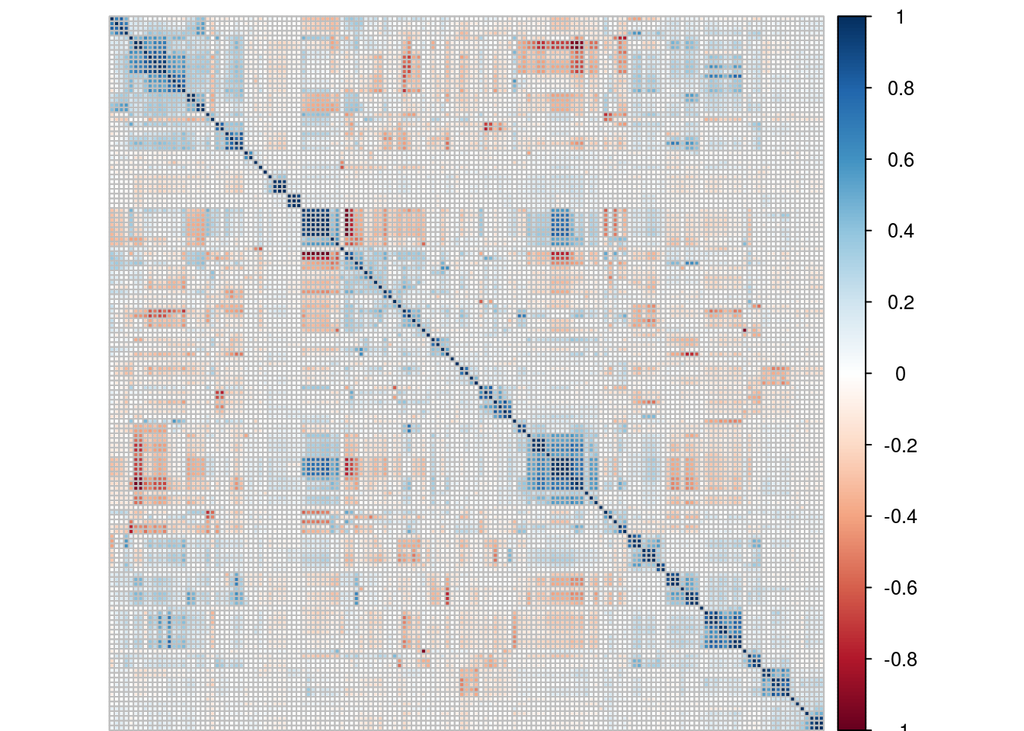

```r
library(corrplot)
corrSubset <- subset(training[,sapply(training,is.numeric)],
                     select = -c(kurtosis_yaw_belt,
                                 skewness_yaw_belt,
                                 kurtosis_yaw_dumbbell,
                                 skewness_yaw_dumbbell,
                                 kurtosis_yaw_forearm,
                                 skewness_yaw_forearm))
correlation <- cor(corrSubset, use = "na.or.complete")
corrplot(correlation, order = "hclust", tl.pos = "n")
```

Overall, you can see there is significant correlation between variables. Intuitively, this makes sense because if the subject moves in a certain way multiple times the readings from the various sensors will be similar (and hence correlated). This means that if it can be determined which movements are correlated with each movement class then we should be able to predict the class given movement information.

Due to the number of variables and considering the colinearity, the variables with greater than 5% correlation with the response variable were extracted:

```r
classeCor <- sapply(names(corrSubset), function(col) {
    cor(corrSubset[,col], as.numeric(training$classe))
})
classeCor <- classeCor[!is.na(classeCor)]
classeCor <- classeCor[abs(classeCor) >= 0.05]
classeCor <- classeCor[order(abs(classeCor), decreasing = TRUE)]
correlatedVars <- names(classeCor)
```

## Data Modeling

To compare the predictive capacity of the variables correlated to the response and including all the variables a Classification and Regression Tree (CART) model was built for each subset:

```r
# Data Modeling
library(caret)
library(doMC)
registerDoMC()
set.seed(1031)

controlObject <- trainControl(method = "cv", number = 10, verboseIter=TRUE)

## CART Model Using Highly Correlated Variables
cartModelCorVar <- train(x = subset(training, select = correlatedVars),
                         y = training$classe,
                         method = "rpart",
                         trControl = controlObject)
print(cartModelCorVar)
```

```
## CART
##
## 19622 samples
##    24 predictors
##     5 classes: 'A', 'B', 'C', 'D', 'E'
##
## No pre-processing
## Resampling: Cross-Validated (10 fold)
##
## Summary of sample sizes: 17660, 17659, 17660, 17659, 17661, 17659, ...
##
## Resampling results across tuning parameters:
##
##   cp    Accuracy  Kappa  Accuracy SD  Kappa SD
##   0.03  0.5       0.4    0.04         0.05
##   0.04  0.5       0.3    0.05         0.1
##   0.1   0.3       0.07   0.04         0.06
##
## Accuracy was used to select the optimal model using  the largest value.
## The final value used for the model was cp = 0.03.
```

```r
## CART Model Using All Variables
cartModel <- train(x = subset(training, select = -classe),
                   y = training$classe,
                   method = "rpart",
                   trControl = controlObject)
print(cartModel)
```

```
## CART
##
## 19622 samples
##   158 predictors
##     5 classes: 'A', 'B', 'C', 'D', 'E'
##
## No pre-processing
## Resampling: Cross-Validated (10 fold)
##
## Summary of sample sizes: 17659, 17660, 17661, 17659, 17662, 17659, ...
##
## Resampling results across tuning parameters:
##
##   cp    Accuracy  Kappa  Accuracy SD  Kappa SD
##   0.06  0.6       0.4    0.02         0.03
##   0.1   0.5       0.4    0.04         0.06
##   0.3   0.4       0.1    0.09         0.2
##
## Accuracy was used to select the optimal model using  the largest value.
## The final value used for the model was cp = 0.06.
```

The Naive Bayes and Bagged CART models were fitted to the dataset.

```r
## Naive Bayes Model Using Highly Correlated Variables
naiveBayesModel <- train(x = subset(training, select = correlatedVars),
                         y = training$classe,
                         method = "nb",
                         trControl = controlObject)
print(naiveBayesModel)
```

```
## Naive Bayes
##
## 19622 samples
##    24 predictors
##     5 classes: 'A', 'B', 'C', 'D', 'E'
##
## No pre-processing
## Resampling: Cross-Validated (10 fold)
##
## Summary of sample sizes: 17660, 17660, 17659, 17661, 17660, 17659, ...
##
## Resampling results across tuning parameters:
##
##   usekernel  Accuracy  Kappa  Accuracy SD  Kappa SD
##   FALSE      0.5       0.3    0.01         0.01
##   TRUE       0.7       0.6    0.01         0.01
##
## Tuning parameter 'fL' was held constant at a value of 0
## Accuracy was used to select the optimal model using  the largest value.
## The final values used for the model were fL = 0 and usekernel = TRUE.
```

```r
## Bagged CART Model Using Highly Correlated Variables
baggedCartModel <- train(x = subset(training, select = correlatedVars),
                         y = training$classe,
                         method = "treebag",
                         trControl = controlObject)
print(baggedCartModel)
```

```
## Bagged CART
##
## 19622 samples
##    24 predictors
##     5 classes: 'A', 'B', 'C', 'D', 'E'
##
## No pre-processing
## Resampling: Cross-Validated (10 fold)
##
## Summary of sample sizes: 17660, 17660, 17660, 17660, 17660, 17660, ...
##
## Resampling results
##
##   Accuracy  Kappa  Accuracy SD  Kappa SD
##   1         1      0.002        0.003
##
##
```

```r
# Data Prediction

predictions <- predict(baggedCartModel, newdata = testing)
```

The Bagged CART model has an accuracy of 98.1% compared to an accuracy of 65.4% for Naive Bayes using 10-fold cross validation.